# Pitcher card

# Nick Mears

RHP · KC

2026 · 21 G (0 GS) · 341 pitches · Mar 30 – May 27, 2026

Independent portfolio sample by Devin Jenkinson, not affiliated with any club. Every number is computed from public Statcast data.

Three big takeaways

1Watch

The slider is his most-used two-strike pitch.

42% of two-strike pitches · 26 two-strike swings so far

No pitch has 50+ two-strike swings yet, so this card does not name a put-away pitch by miss rate.

2Watch

xRV/100 +0.18 shrunk · 125 pitches

Shrunk toward the league average for the pitch type (250-pitch prior), so small edges are real but modest.

3Watch

Build the 4-seam fastball sample before setting a height plan.

29 swings up · 11 swings down

Rates under 50 swings are not quoted on this card.

Charts

### Movement

The CU finishes 36 in from his FF, with 34 in less rise.

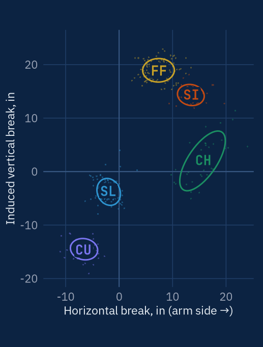

n = 341 pitches. Ellipses hold about 68% of each type; codes sit at the averages.

### Location by count

He fills the zone at about the same rate ahead (53%) and behind (51%).

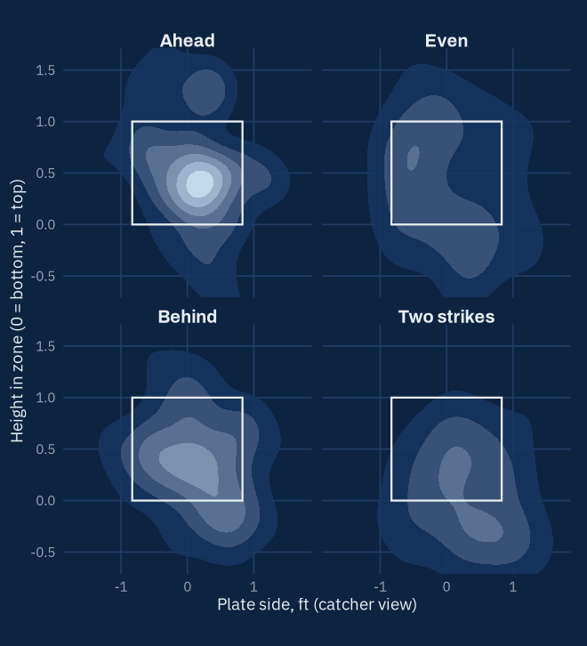

n = 341. Ahead 38 · even 113 · behind 81 · two strikes 109 pitches. Box = rule-book zone.

### Put-away

The SL is 42% of two-strike pitches vs 27% overall.

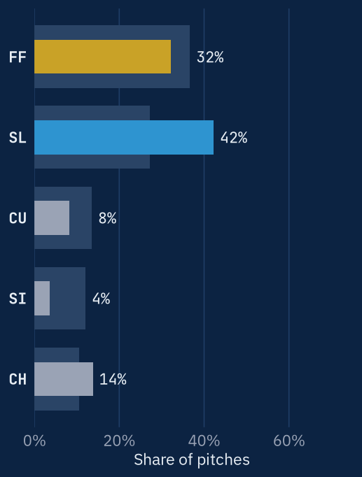

Two-strike n: SL 46, FF 35, CH 15, CU 9, SI 4. Grey bars = overall usage; wh = whiffs per swing (shown with 50+ swings).

### Arsenal

| Pitch | # | Use | Velo | IVB | HB | VAA | Whiff | Chase | xwOBAcon | xRV/100 | Stuff+ |
| --- | --- | --- | --- | --- | --- | --- | --- | --- | --- | --- | --- |
| 4-Seam (FF) | 125 | 37% | 94.8 | 18.9 | +7.5 | -5.0 | 9% | 24% | .340 | +0.18 | 111 |
| Slider (SL) | 93 | 27% | 84.6 | -3.6 | -2.0 | -8.8 | 30% | 43% | .567 | -0.65 | 93 |
| Curveball (CU) | 46 | 13% | 81.4 | -14.6 | -6.7 | -10.1 | 27% | 22% | .478 | -0.19 | 93 |
| Sinker (SI) | 41 | 12% | 93.8 | 14.4 | +13.5 | -5.6 | 4% | 20% | .448 | +0.26 | 92 |
| Changeup (CH) | 36 | 11% | 84.5 | 2.2 | +15.7 | -8.5 | 33% | 27% | .180 | -0.07 | 111 |

IVB / HB in inches (HB + = arm side). VAA in degrees at the front of the plate. xRV/100 = expected run value per 100 pitches, pitcher’s view, shrunk with a 250-pitch prior. Stuff+ = this project’s shape-only model (100 = MLB average, 10 = 1 SD).

### Vs. batter hand

| Pitch | LHH # | Use | Whiff | xwOBAcon | RHH # | Use | Whiff | xwOBAcon |
| --- | --- | --- | --- | --- | --- | --- | --- | --- |
| FF | 75 | 40% | – | .290 | 50 | 33% | – | .557 |
| SL | 34 | 18% | – | .412 | 59 | 39% | – | .390 |
| CU | 34 | 18% | – | .250 | 12 | 8% | – | .455 |
| SI | 10 | 5% | – | .344 | 31 | 20% | – | .429 |
| CH | 36 | 19% | – | .264 | – | – | – | – |

Use = share of pitches to that side. Whiff = whiffs per swing, shown with 50+ swings.